# Project4 Red Wine Quality Exploration by Jing

Here is the scatter plot of fixed acidity for each quality levels:

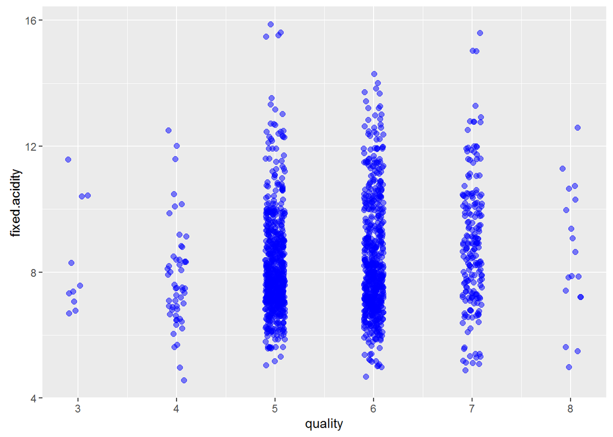

Here is the box plot of fixed acidity for each quality levels (X is the position of mean) :

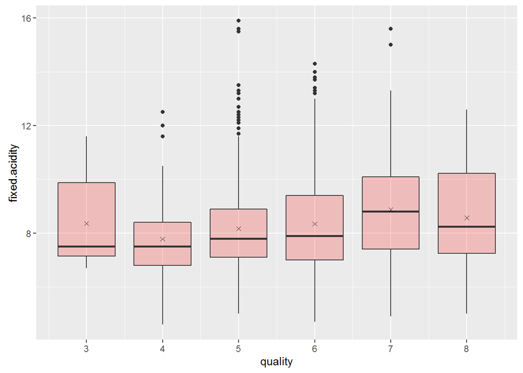

From this box plot, I would see the correlation of fixed acidity and quality level is too weak to have the fixed acidity to be the good prediction feature.

The following is the statistic summary of fixed acidity by quality level.

```
## $`3`
##    Min. 1st Qu.  Median    Mean 3rd Qu.    Max.
##   6.700   7.150   7.500   8.360   9.875  11.600
##
## $`4`
##    Min. 1st Qu.  Median    Mean 3rd Qu.    Max.
##   4.600   6.800   7.500   7.779   8.400  12.500
##
## $`5`
##    Min. 1st Qu.  Median    Mean 3rd Qu.    Max.
##   5.000   7.100   7.800   8.167   8.900  15.900
##
## $`6`
##    Min. 1st Qu.  Median    Mean 3rd Qu.    Max.
##   4.700   7.000   7.900   8.347   9.400  14.300
##
## $`7`
##    Min. 1st Qu.  Median    Mean 3rd Qu.    Max.
##   4.900   7.400   8.800   8.872  10.100  15.600
##
## $`8`
##    Min. 1st Qu.  Median    Mean 3rd Qu.    Max.
##   5.000   7.250   8.250   8.567  10.230  12.600
```

Besides the main features of interets, I would like to explore the relationship of fixed.acidity and total.acidity.

Here is the scatter plot:

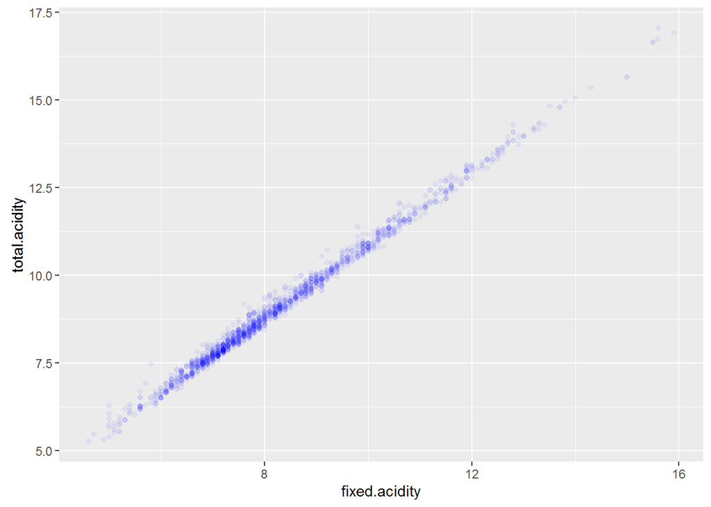

From the plot above, we can see they almost have a liner relationship with the following coefficients.

```
##
## Call:
## lm(formula = total.acidity ~ fixed.acidity, data = wineData)
##
## Coefficients:
##   (Intercept)  fixed.acidity
##        0.3927         1.0488
```

# Bivariate Analysis

### Talk about some of the relationships you observed in this part of the investigation. How did the feature(s) of interest vary with other features in the dataset?

volatile acid which has a negative correlation with quality, which is -0.391.It shows a clear trend in the box plot that the wine with higher volatile acidity has lower quality levels. This can be understood since too high levels of volatile acid can lead to an unpleasant, vinegar taste.

Sulphates and quality has the correlation of 0.251. Box plot shows likely trend that wine contain higher sulphates has higher quality level based on the statistic box plot.

The next one is citric acid with the correlation of 0.226. Althought the citric acid for each quality level is widely distributed, it is more likely that wine with higer containing of citric acid have better quality as shown in box plot. The citric acid can add ‘freshness’ and flavor to wines.

### Did you observe any interesting relationships between the other features (not the main feature(s) of interest)?

Besides the main features of interets, I noticed that fixed.acidity and total.acidity has a strong linear relationship. This can be understood since the ratio of fixed.acidity is way higher than the other two when being calculated.

# Multivariate Plots Section

Since the alcohol has the strongest correlation of Quality, I decided to use alcohol and quality as y and x for all the multivariate plot. The median of alcohol concentration is denoted as “+” in each figure. The third variables are plotted as change of colors.

1. Quality, alcohol and volatile.acidity:

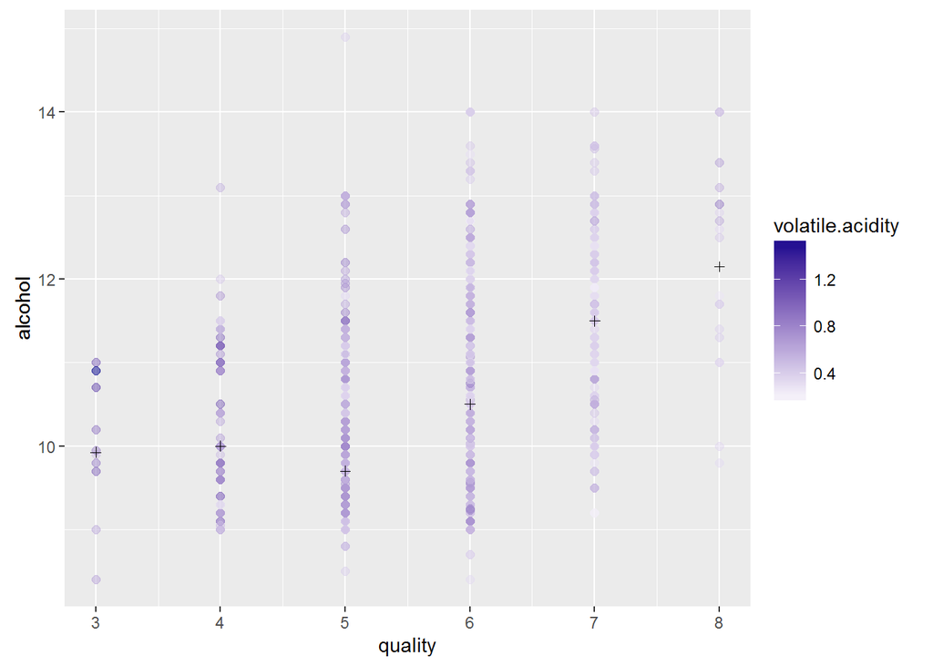

It clearly show that lower quality with a darker color which means more volatile acidity which is consistent with the finding from bivariable part.

The I tried to jitter a little bit in order to have a better visulization.

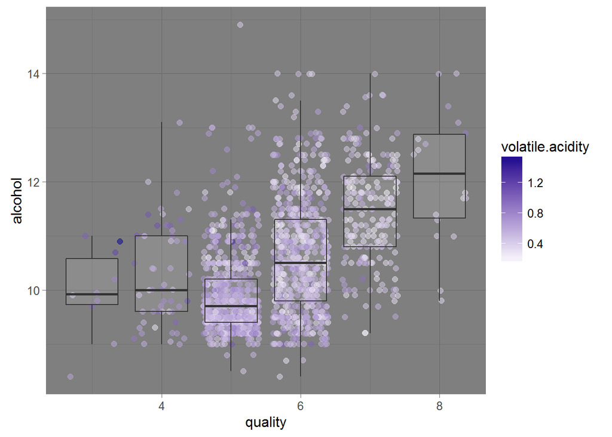

It seems better, so I decided to use this plot as the template for the rest of the variables.

2. Quality, alcohol and sulphates:

plot without jitter:

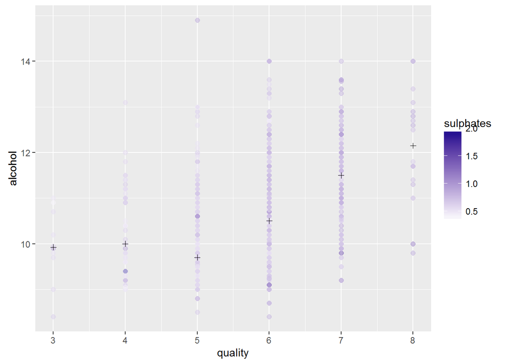

plot with jitter:

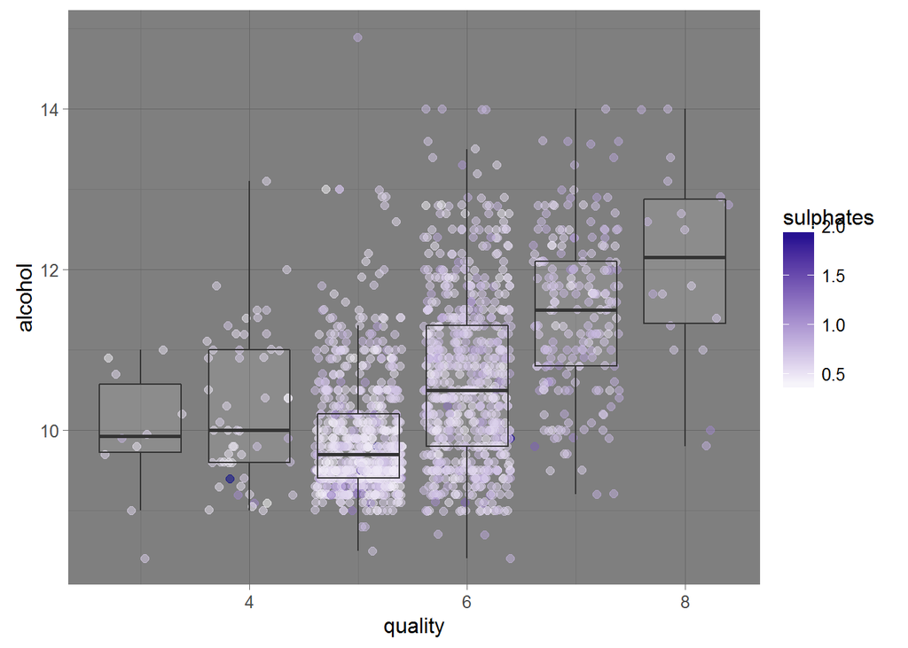

It clearly show that lower quality with a shallower color that represents less sulphates, which is consistent with the finding from bivariable part.

3. Quality, alcohol and citric.acid:

plot without jitter:

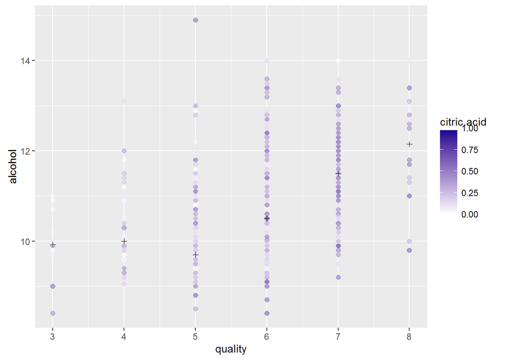

Plot with jitter:

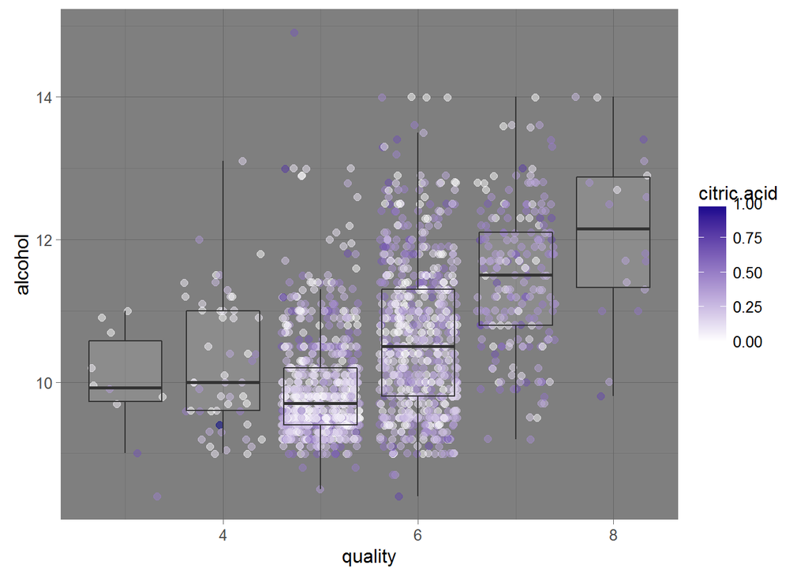

It is a not quit clear, but it seems show that lower quality with a shallower color that represents less citric acid, which is consistent with the finding from bivariable part.

These 3 plots suggest that we can build a linear model and use those variables in the linear model to predict the quality of wine.

```
##
## Calls:
## m1: lm(formula = quality ~ alcohol, data = wineData)
## m2: lm(formula = quality ~ alcohol + volatile.acidity, data = wineData)
## m3: lm(formula = quality ~ alcohol + volatile.acidity + sulphates,
##     data = wineData)
## m4: lm(formula = quality ~ alcohol + volatile.acidity + sulphates +
##     citric.acid, data = wineData)
##
## ================================================================
##                        m1         m2         m3         m4
## ----------------------------------------------------------------
##   (Intercept)        1.875***   3.095***   2.611***   2.646***
##                     (0.175)    (0.184)    (0.196)    (0.201)
##   alcohol            0.361***   0.314***   0.309***   0.309***
##                     (0.017)    (0.016)    (0.016)    (0.016)
##   volatile.acidity             -1.384***  -1.221***  -1.265***
##                                (0.095)    (0.097)    (0.113)
##   sulphates                                0.679***   0.696***
##                                           (0.101)    (0.103)
##   citric.acid                                        -0.079
##                                                      (0.104)
## ----------------------------------------------------------------
##   R-squared              0.2        0.3        0.3        0.3
##   adj. R-squared         0.2        0.3        0.3        0.3
##   sigma                  0.7        0.7        0.7        0.7
##   F                    468.3      370.4      268.9      201.8
##   p                      0.0        0.0        0.0        0.0
##   Log-likelihood     -1721.1    -1621.8    -1599.4    -1599.1
##   Deviance             805.9      711.8      692.1      691.9
##   AIC                 3448.1     3251.6     3208.8     3210.2
##   BIC                 3464.2     3273.1     3235.7     3242.4
##   N                   1599       1599       1599       1599
## ================================================================
```

The variables in this linear model can account for only 30% of the variance in the quality of wines.

# Multivariate Analysis

### Were there any interesting or surprising interactions between features?

From the color plot for variables of volatile acidity, sulphates and citric acid, I found all of them have a wide distribution which give a roughly trend with correlation of wine quality.

### OPTIONAL: Did you create any models with your dataset? Discuss the strengths and limitations of your model.

Yes, I created a linear model using concentration of alcohol, volatile acidity, sulphates and citric acid to predict the level of quality. However, the variables in this linear model can only account for 30% of the variance in the quality of wines.

# Final Plots and Summary

### Plot One

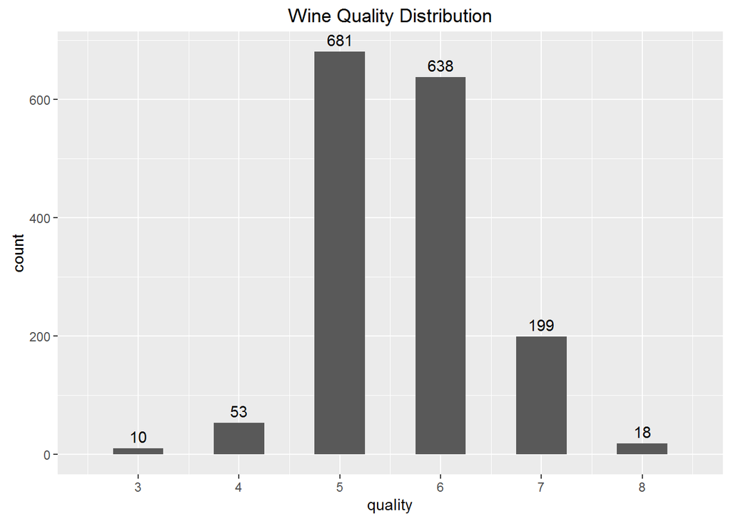

### Description One

From this wine quality distribution histogram we can see the most of the wines have the quality of 5 or 6 which give us an un-uniform data for analysis. It is a very good plot to know the distribution of the qualities of the wine.

### Plot Two

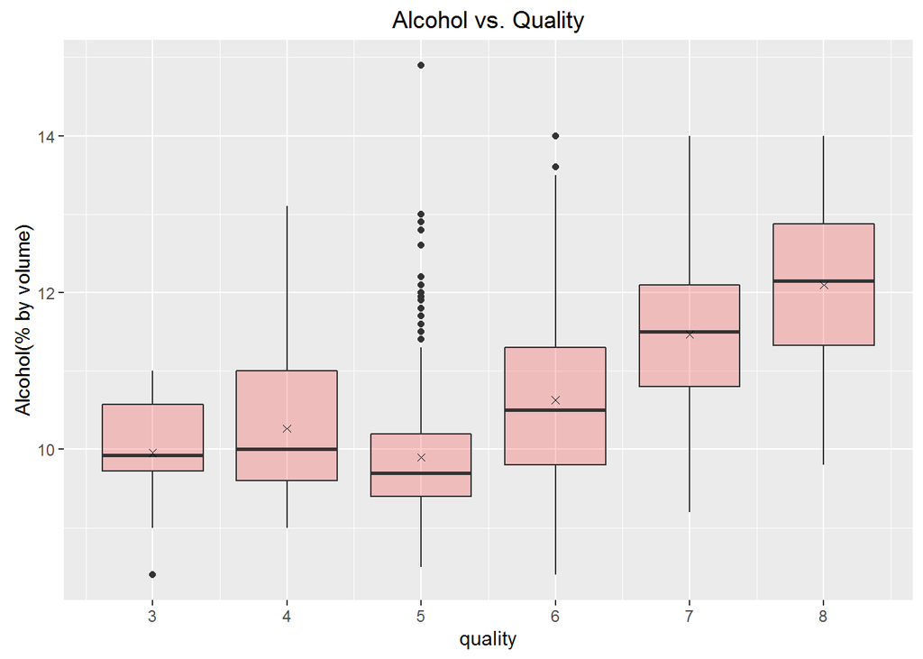

### Description Two

From the box plot of Alcohol vs. Quality, It looks like wine with higher alcohol concentraion has higher quality level espeically true when quality level is higher than 5. I chose this picture because it reprensents the relationship of quality and its most related variable according to the correlation data.

### Plot Three

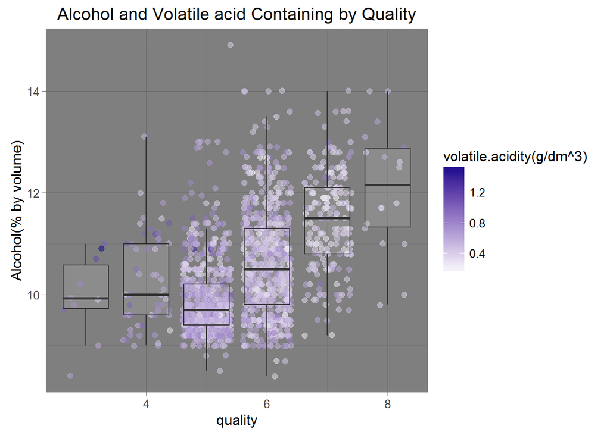

### Description Three

This plot is using alcohol as y axis, quality as x axis, boxplot shows the distribution of alcohol data. It clearly show that the median of alcohol increase as the quality increases when quality level is greater than 5. The volatile acidity is ploted as the changes of color. it shows lower quality with a darker color which means more volatile acidity. This plot was chosen due to it contain the relationship of quality and its top 2 relevant variables.

# Reflection

This wineData contains information on 1599 kinds of red wine with 12 features. I tried to understand the dataset by ploting all the indiviual variables. Then, I tried to find the relationship of all the features in pairs. Following by find all the related features to the wine quality. Finally, I explore all these variables and created a linear model to predict wine quality. The following are some struggles I experienced during the data exploration:

1. At first glance of the data, I thought all the acid like fixed acidity, volatile acidity and citric acid should contribute the same to the taste of the wine since they are all acid.Thus, I add them up to see if the total acid variable will give me a better way to create a better prediciton model. However, after exploring the relationship by pair, I found them works the opposite way. volatile acid will lead a bad taste while citric acid can fresh the wine. Furthur more, since the ratio of fixed acid is super high, it actually dominate the performance of the total acid variable. With these consideration, I have to give up the idea of total acid.
2. In the R classes provided by udacity, for the multivate plot, it used the discrete data as the third variable. However, for my plot, I have to use continuous variable as the third variable to be colored. Acutully, I stucked here for a long time. I googled online but can not get any idea how to deal with this situation. Even Stackoverflow.com did not help. I struggled for a long time until I finally go to the ggplot documentation directly. This experience tells me it is a better way to first refer to a full documentation than randomly asking questions on line next time.
3. Although I create a linear model for prediction the quality of wine, I do not think it is a trusted model. Here are some thoughts I came up: First, the distribution of quality is too un-uniform, the data are centred in quality level 5 and 6, for the other quality levels, the data points are too less to provide a trustable model. Second, I would say, there must be a more complicated model here, since these listed chemicals may have a very complicated reaction with the taste of human beings. It can not be described by the simple mathmatic equations. Third, there might be other features in the red wine which are not listed in datasets.
4. Future work: Based on the discussion on last paragraph, I would like to suggest to include more datasets with nearly same number of data for each quality levels. The features like the region of production, weather condition for the year, soil condition for the grapes and technical process of production might be include for a prediction model. Also, I think, the model might include some chemical reaction as well as the physiological and Psychological reactions in human body.

# Reference

[1]P. Cortez, A. Cerdeira, F. Almeida, T. Matos and J. Reis. Modeling wine preferences by data mining from physicochemical properties. In Decision Support Systems, Elsevier, 47(4):547-553. ISSN: 0167-9236. Available at: [@Elsevier] http://dx.doi.org/10.1016/j.dss.2009.05.016 [Pre-press (pdf)] http://www3.dsi.uminho.pt/pcortez/winequality09.pdf [bib] http://www3.dsi.uminho.pt/pcortez/dss09.bib

[2]http://www.statmethods.net/input/datatypes.html [3]http://stackoverflow.com/tags/r/info [4]http://docs.ggplot2.org/current/